# Uso de Api de Covid19 con Pandas

En esta actividad trabajaremos con esta api: [covid19api](https://api.covid19api.com/countries)

## Instalación Pandas

Primero, debemos instalar la librería que vayamos a usar. En este caso trabajaremos con una librería Pandas que sirve para trabajar con datos. A pesar de que Anaconda tenga su propio gestor de paquete y se use `condas` para añadir la librería, vamos a utilizar el estandar. Es decir, `pip`.

```python
!pip install pandas
```

## Configuración

Para configurar pandas debemos añadir la siguiente configuración. De esta manera, cada vez que llame a pandas le llamaré como `pd`. Añadimos pd porque es la manera común de realizarlo, pero en su lugar sería posible añadir cualquier palabra.

```python
import pandas as pd
```

## Variables

A continuación, añadiremos la variable. En este caso es la url en la que estan todos los países. Como podemos observar funciona adecuadamente, ya que al añadir `url`nos la devuelve.

```python
url = 'https://api.covid19api.com/countries'
url
```

```
'https://api.covid19api.com/countries'
```

## Creación de *Dataframe*

Como vamos a trabajar con tablas, lo siguiente que haremos será crear el `dataframe`. Así, traeremos los datos de la api a una tabla. Utilizamos la función `read_jason` de *Pandas* para leer los datos en *JSON* de la *API*, puesto que tal y como se puede leer en la web `covid19api.com` API con la que estamos trabajando devuelve los datos en JSON.

```python
df = pd.read_json (url)
```

A continuación, utilizaremos unas funciones clasicas para trabajar con los datos. Analizaremos la cabecera, la cola y la descripción. Podemos añadir dentro del parentesis el número de filas que queremos visualizar en cada función que le pedimos. Así, obtendremos las cinco primeras filas, las últimas y la descripción de los datos como por ejemplo la cantidad de países y cuál es el que se encuentra en primera fila.

```python
df.head(5)
```

|  | Country | Slug | ISO2 |
| --- | --- | --- | --- |
| 0 | Honduras | honduras | HN |
| 1 | Nicaragua | nicaragua | NI |
| 2 | Tunisia | tunisia | TN |
| 3 | Gibraltar | gibraltar | GI |
| 4 | South Georgia and the South Sandwich Islands | south-georgia-and-the-south-sandwich-islands | GS |

```python
df.tail ()
```

|  | Country | Slug | ISO2 |
| --- | --- | --- | --- |
| 243 | Holy See (Vatican City State) | holy-see-vatican-city-state | VA |
| 244 | Lesotho | lesotho | LS |
| 245 | Norfolk Island | norfolk-island | NF |
| 246 | Palau | palau | PW |
| 247 | Wallis and Futuna Islands | wallis-and-futuna-islands | WF |

```python
df.describe ()
```

|  | Country | Slug | ISO2 |
| --- | --- | --- | --- |
| count | 248 | 248 | 248 |
| unique | 248 | 248 | 248 |
| top | Honduras | honduras | HN |
| freq | 1 | 1 | 1 |

Con el `dataframe` podemos obtener un resumen de la información de la tabla: que tiene 248 entradas, 3 columnas con 3 tipos de objetos... así nos aseguramos de que las celdas no esten vacías.

```python
df.info()
```

```
<class 'pandas.core.frame.DataFrame'>
RangeIndex: 248 entries, 0 to 247
Data columns (total 3 columns):
 #   Column   Non-Null Count  Dtype
---  ------   --------------  -----
 0   Country  248 non-null    object
 1   Slug     248 non-null    object
 2   ISO2     248 non-null    object
dtypes: object(3)
memory usage: 5.9+ KB
```

Como lo que tenemos es una lista con diferentes columnas, mediante los corchetes podemos pedirle que nos saque tan solo una de las columnas. Así, nos devuelve un extracto con los primeros y los últimos valores de esa columna.

```python
df['Country']
```

```
0                                          Honduras
1                                         Nicaragua
2                                           Tunisia
3                                         Gibraltar
4      South Georgia and the South Sandwich Islands
                           ...
243                   Holy See (Vatican City State)
244                                         Lesotho
245                                  Norfolk Island
246                                           Palau
247                       Wallis and Futuna Islands
Name: Country, Length: 248, dtype: object
```

También podemos pedirle un valor exacto añadiendo el índice entre corchetes.

```python
df['Country'] [200]
```

```
'Bangladesh'
```

## Tiempo real España

Para consultal el tiempo real lo primero que haremos será añadir la *URL*. Para diferenciarla de la *URL* anterior le llamaremos `url_live`. Podríamos llamarla `urlLive`, pero NO `url-live`, debido a que es un código reservado de Python. Despuès crearemos el `dataframe`. Lo llamaremos `df_es`

```python
url_live =  'https://api.covid19api.com/country/spain/status/confirmed/live'
df_es = pd.read_json(url_live)
df_es
```

|  | Country | CountryCode | Province | City | CityCode | Lat | Lon | Cases | Status | Date |
| --- | --- | --- | --- | --- | --- | --- | --- | --- | --- | --- |
| 0 | Spain | ES |  |  |  | 40.46 | -3.75 | 0 | confirmed | 2020-01-22 00:00:00+00:00 |
| 1 | Spain | ES |  |  |  | 40.46 | -3.75 | 0 | confirmed | 2020-01-23 00:00:00+00:00 |
| 2 | Spain | ES |  |  |  | 40.46 | -3.75 | 0 | confirmed | 2020-01-24 00:00:00+00:00 |
| 3 | Spain | ES |  |  |  | 40.46 | -3.75 | 0 | confirmed | 2020-01-25 00:00:00+00:00 |
| 4 | Spain | ES |  |  |  | 40.46 | -3.75 | 0 | confirmed | 2020-01-26 00:00:00+00:00 |
| ... | ... | ... | ... | ... | ... | ... | ... | ... | ... | ... |
| 814 | Spain | ES |  |  |  | 40.46 | -3.75 | 11627487 | confirmed | 2022-04-15 00:00:00+00:00 |
| 815 | Spain | ES |  |  |  | 40.46 | -3.75 | 11627487 | confirmed | 2022-04-16 00:00:00+00:00 |
| 816 | Spain | ES |  |  |  | 40.46 | -3.75 | 11627487 | confirmed | 2022-04-17 00:00:00+00:00 |
| 817 | Spain | ES |  |  |  | 40.46 | -3.75 | 11627487 | confirmed | 2022-04-18 00:00:00+00:00 |
| 818 | Spain | ES |  |  |  | 40.46 | -3.75 | 11627487 | confirmed | 2022-04-19 00:00:00+00:00 |

819 rows × 10 columns

```python
df.info()
```

```
<class 'pandas.core.frame.DataFrame'>
RangeIndex: 248 entries, 0 to 247
Data columns (total 3 columns):
 #   Column   Non-Null Count  Dtype
---  ------   --------------  -----
 0   Country  248 non-null    object
 1   Slug     248 non-null    object
 2   ISO2     248 non-null    object
dtypes: object(3)
memory usage: 5.9+ KB
```

También podemos convertir la columna que nosotros queremos en la primera. Es decir, en el index. Así, mediante el siguiente código le decimos que nos muestre en el indice la columna fecha.

```python
df_es.set_index('Date')
```

| Date | Country | CountryCode | Province | City | CityCode | Lat | Lon | Cases | Status |
| --- | --- | --- | --- | --- | --- | --- | --- | --- | --- |
| 2020-01-22 00:00:00+00:00 | Spain | ES |  |  |  | 40.46 | -3.75 | 0 | confirmed |
| 2020-01-23 00:00:00+00:00 | Spain | ES |  |  |  | 40.46 | -3.75 | 0 | confirmed |
| 2020-01-24 00:00:00+00:00 | Spain | ES |  |  |  | 40.46 | -3.75 | 0 | confirmed |
| 2020-01-25 00:00:00+00:00 | Spain | ES |  |  |  | 40.46 | -3.75 | 0 | confirmed |
| 2020-01-26 00:00:00+00:00 | Spain | ES |  |  |  | 40.46 | -3.75 | 0 | confirmed |
| ... | ... | ... | ... | ... | ... | ... | ... | ... | ... |
| 2022-04-15 00:00:00+00:00 | Spain | ES |  |  |  | 40.46 | -3.75 | 11627487 | confirmed |
| 2022-04-16 00:00:00+00:00 | Spain | ES |  |  |  | 40.46 | -3.75 | 11627487 | confirmed |
| 2022-04-17 00:00:00+00:00 | Spain | ES |  |  |  | 40.46 | -3.75 | 11627487 | confirmed |
| 2022-04-18 00:00:00+00:00 | Spain | ES |  |  |  | 40.46 | -3.75 | 11627487 | confirmed |
| 2022-04-19 00:00:00+00:00 | Spain | ES |  |  |  | 40.46 | -3.75 | 11627487 | confirmed |

819 rows × 9 columns

También podemos decidir que datos son los que queremos visualizar:

```python
df_es.set_index('Date')['Cases']
```

```
Date
2020-01-22 00:00:00+00:00           0
2020-01-23 00:00:00+00:00           0
2020-01-24 00:00:00+00:00           0
2020-01-25 00:00:00+00:00           0
2020-01-26 00:00:00+00:00           0
                               ...
2022-04-15 00:00:00+00:00    11627487
2022-04-16 00:00:00+00:00    11627487
2022-04-17 00:00:00+00:00    11627487
2022-04-18 00:00:00+00:00    11627487
2022-04-19 00:00:00+00:00    11627487
Name: Cases, Length: 819, dtype: int64
```

Seguido de los datos que queremos, añadiremos otra función. Para eso utilizaremos el `.` para separar el `dataframe`de esta función. Con `plot`conseguiremos que nos haga un gráfico con estos dos datos.

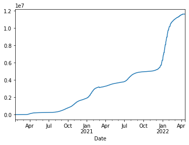

```python
df_es.set_index('Date')['Cases'].plot()
```

También es posible añadir un título a este mismo gráfico añadiendo un parentesis y el nombre que queramos darle.

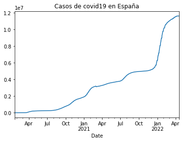

```python
df_es.set_index('Date')['Cases'].plot(title="Casos de covid19 en España")
```

A continuación, sacamos el tiempo real en Colombia de la misma manera que hemos obtenido los datos de España.

## Tiempo real colombia

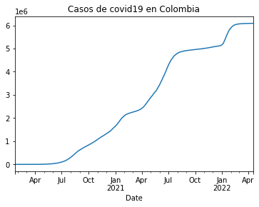

```python
url_co =  'https://api.covid19api.com/country/colombia/status/confirmed/live'
df_co = pd.read_json(url_co)
df_co.set_index('Date')['Cases'].plot(title="Casos de covid19 en Colombia")
```

## Comparativa España-Colombia

También podemos realizar la comparativa entre ambos países.

```python
casos_es = df_es.set_index('Date')['Cases']
casos_co = df_co.set_index('Date')['Cases']
```

```python
casos_es
```

```
Date
2020-01-22 00:00:00+00:00           0
2020-01-23 00:00:00+00:00           0
2020-01-24 00:00:00+00:00           0
2020-01-25 00:00:00+00:00           0
2020-01-26 00:00:00+00:00           0
                               ...
2022-04-15 00:00:00+00:00    11627487
2022-04-16 00:00:00+00:00    11627487
2022-04-17 00:00:00+00:00    11627487
2022-04-18 00:00:00+00:00    11627487
2022-04-19 00:00:00+00:00    11627487
Name: Cases, Length: 819, dtype: int64
```

Para mostrar los datos de estos países en una tabla los concatenamos. Índicando que el eje es uno, para que los datos se muestren a la derecha.

```python
pd.concat([casos_es,casos_co],axis=1)
```

| Date | Cases | Cases |
| --- | --- | --- |
| 2020-01-22 00:00:00+00:00 | 0 | 0 |
| 2020-01-23 00:00:00+00:00 | 0 | 0 |
| 2020-01-24 00:00:00+00:00 | 0 | 0 |
| 2020-01-25 00:00:00+00:00 | 0 | 0 |
| 2020-01-26 00:00:00+00:00 | 0 | 0 |
| ... | ... | ... |
| 2022-04-15 00:00:00+00:00 | 11627487 | 6089381 |
| 2022-04-16 00:00:00+00:00 | 11627487 | 6089540 |
| 2022-04-17 00:00:00+00:00 | 11627487 | 6089662 |
| 2022-04-18 00:00:00+00:00 | 11627487 | 6089791 |
| 2022-04-19 00:00:00+00:00 | 11627487 | 6089998 |

819 rows × 2 columns

Para guardar esta concatenación creamos un objeto, en este caso con el nombre `vs`.

```python
vs = pd.concat([casos_es,casos_co],axis=1)
vs
```

| Date | Cases | Cases |
| --- | --- | --- |
| 2020-01-22 00:00:00+00:00 | 0 | 0 |
| 2020-01-23 00:00:00+00:00 | 0 | 0 |
| 2020-01-24 00:00:00+00:00 | 0 | 0 |
| 2020-01-25 00:00:00+00:00 | 0 | 0 |
| 2020-01-26 00:00:00+00:00 | 0 | 0 |
| ... | ... | ... |
| 2022-04-15 00:00:00+00:00 | 11627487 | 6089381 |
| 2022-04-16 00:00:00+00:00 | 11627487 | 6089540 |
| 2022-04-17 00:00:00+00:00 | 11627487 | 6089662 |
| 2022-04-18 00:00:00+00:00 | 11627487 | 6089791 |
| 2022-04-19 00:00:00+00:00 | 11627487 | 6089998 |

819 rows × 2 columns

Para que la tabla (y más adelante el gráfico) se entienda bien, conviene cambiar el nombre de las columnas y añadir el dato que corresponde a cada una de ellas. He seguido los pasos del profesor, pero no se añade corretamente y no sé cuál es el motivo.

```python
vs.colums = ['España','Colombia']
```

```python
vs
```

| Date | Cases | Cases |
| --- | --- | --- |
| 2020-01-22 00:00:00+00:00 | 0 | 0 |
| 2020-01-23 00:00:00+00:00 | 0 | 0 |
| 2020-01-24 00:00:00+00:00 | 0 | 0 |
| 2020-01-25 00:00:00+00:00 | 0 | 0 |
| 2020-01-26 00:00:00+00:00 | 0 | 0 |
| ... | ... | ... |
| 2022-04-15 00:00:00+00:00 | 11627487 | 6089381 |
| 2022-04-16 00:00:00+00:00 | 11627487 | 6089540 |
| 2022-04-17 00:00:00+00:00 | 11627487 | 6089662 |
| 2022-04-18 00:00:00+00:00 | 11627487 | 6089791 |
| 2022-04-19 00:00:00+00:00 | 11627487 | 6089998 |

819 rows × 2 columns

Se puede realizar una gráfica con la comparación de los dos países. Es posible añadir el area con el complemento `kind`

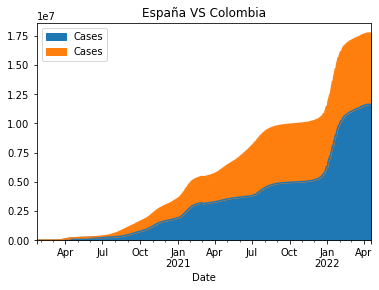

```python
vs.plot(title="España VS Colombia",kind= 'area')
```

## Comparativa de tres países

Ahora, realizaremos la comparativa de tres países.

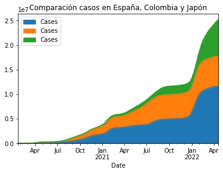

```python
url_jp =  'https://api.covid19api.com/country/japan/status/confirmed/live'
df_jp = pd.read_json(url_jp)
casos_jp = df_jp.set_index('Date')['Cases']
vs3 = pd.concat([casos_es,casos_co,casos_jp],axis=1)

vs3.plot(title="Comparación casos en España, Colombia y Japón",kind= 'area')
```

## Exportar datos

```python
vs3.to_csv('vs3.csv')
```

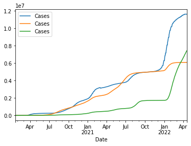

```python
grafico = vs3.plot()
fig = grafico.get_figure()
fig.savefig('vs3.png')
```